# Bayes Classifier (& Naive Bayes Classifiers)

## Bayes Classifier

1. Bayes classifier is classifier based on Bayes decision rule.
2. It minimizes the the probability of misclassification.  
   $P(y|X) = \frac{P(X|y)P(y)}{P(X)}$ (by Baye's theorem)  
   This expressed as  
   $Posterior = \frac{(Class Conditional)*(Prior)}{Marginal}$  
   OR  
   $Posterior = \frac{(Likelihood)*(Prior)}{Evidence}$

$y$ denotes class  
$X$ is feature vetor  
$P(X|y)$ = Class conditional density  
$P(y)$ = Prior Probability

When using Bayes classifier we use Bayes decision rule and assign the $X$ to the class $y$ where $P(y|X)$ is maximum.  
To calculate $P(y|X)$ we need both class conditional density ($P(X|y)$) and prior probability ($P(y)$).  
Consider a two class problem with classes corresponding to $y=0$ and $y=1$.  
Then a feature vector $X_0$ belongs to class $y=1$  
if $P(y=1|X=X_0)>P(y=0|X=X_0)$  
$\implies$ if $\frac{P(X=X_0|y=1)P(y=1)}{P(X=X_0)} > \frac{P(X=X_0|y=0)P(y=0)}{P(X=X_0)}$  
$\implies$ if $P(X=X_0|y=1)P(y=1) > P(X=X_0|y=0)P(y=0)$

#### Generally, we obtain both class conditional density and prior probability from training set

## Naive Bayes Classifiers

Naive Bayes classifiers are a collection of classification algorithms based on Bayes’ Theorem.  
It is not a single algorithm but a family of algorithms where all of them share a common principle, i.e. every pair of features being classified is independent of each other.

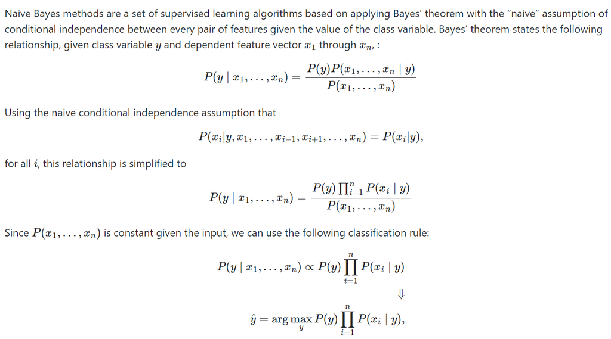

and we can use Maximum A Posteriori (MAP) estimation to estimate $P(y)$ and $P(x_i|y)$, the former is then the relative frequency of class in the training set.

##### The different naive Bayes classifiers differ mainly by the assumptions they make regarding the distribution of $P(x_i|y)$

### Gaussian Naive Bayes Classifier

In Gaussian Naive Bayes algorithm for classification. The likelihood of the features is assumed to be Gaussian:

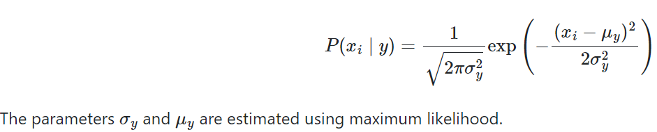

|  | X1 | X2 | Y |
| --- | --- | --- | --- |
| 0 | 1.690526 | 1.098643 | 0 |
| 1 | -0.465937 | 3.189544 | 0 |
| 2 | 0.032820 | -0.576630 | 0 |
| 3 | 0.407516 | 6.098793 | 0 |
| 4 | -0.788923 | 3.167051 | 0 |
| 5 | 0.002066 | 2.514893 | 0 |
| 6 | -0.000890 | 6.144940 | 0 |
| 7 | -1.754724 | 0.697849 | 0 |
| 8 | 1.017658 | 5.070859 | 0 |
| 9 | 0.600499 | -0.128830 | 0 |
| 10 | -0.625429 | 2.675681 | 0 |
| 11 | -0.171548 | 1.591560 | 0 |
| 12 | 0.505299 | 6.923951 | 0 |
| 13 | -0.261356 | 7.532322 | 0 |
| 14 | -0.242749 | 3.341172 | 0 |
| 15 | -1.453241 | 5.681466 | 0 |
| 16 | 0.554580 | 3.640027 | 0 |
| 17 | 0.123881 | 5.136124 | 0 |
| 18 | 0.274460 | 2.494326 | 0 |
| 19 | -1.526525 | 0.583322 | 0 |
| 20 | 1.650700 | 0.393803 | 0 |
| 21 | 0.154336 | 4.766244 | 0 |
| 22 | -0.387140 | 8.495190 | 0 |
| 23 | 2.029072 | 4.538823 | 0 |
| 24 | -0.045386 | 2.950791 | 0 |
| 25 | 8.824038 | 0.654706 | 1 |
| 26 | 5.474604 | 0.894352 | 1 |
| 27 | 5.202868 | 0.415503 | 1 |
| 28 | 5.505155 | -0.923545 | 1 |
| 29 | 4.735246 | -0.196027 | 1 |
| 30 | 4.381047 | -0.590770 | 1 |
| 31 | 2.130073 | -0.299711 | 1 |
| 32 | 6.003248 | 1.296885 | 1 |
| 33 | 4.810449 | 1.529580 | 1 |
| 34 | 7.386172 | 0.669418 | 1 |
| 35 | 4.262363 | 0.548745 | 1 |
| 36 | 1.187260 | 0.676629 | 1 |
| 37 | 4.800779 | -0.012242 | 1 |
| 38 | 8.399075 | -0.075663 | 1 |
| 39 | 4.233154 | -0.673645 | 1 |
| 40 | 3.220286 | -0.055867 | 1 |
| 41 | 2.612816 | 2.259947 | 1 |
| 42 | 2.899966 | 0.869039 | 1 |
| 43 | 4.399613 | -0.342117 | 1 |
| 44 | 2.640036 | -0.471927 | 1 |
| 45 | 7.995278 | -0.864490 | 1 |
| 46 | 4.434730 | 0.374370 | 1 |
| 47 | 5.217297 | 0.391546 | 1 |
| 48 | 7.876479 | -1.443122 | 1 |
| 49 | 8.006637 | 0.486335 | 1 |
| 50 | 4.574534 | -0.569472 | 1 |
| 51 | 5.663948 | 1.426721 | 1 |
| 52 | 6.470053 | 0.156844 | 1 |
| 53 | 4.614289 | 1.717730 | 1 |
| 54 | 1.443974 | -0.458127 | 1 |

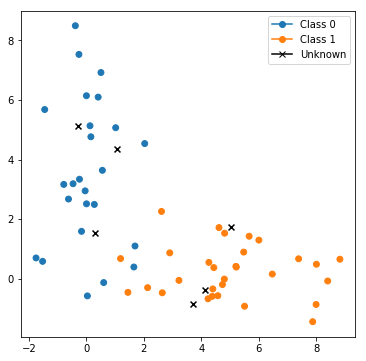

```python
import numpy as np
import matplotlib.pyplot as plt
import pandas as pd
from matplotlib.lines import Line2D
plt.figure(figsize=(6, 6))
legend_elements = [Line2D([0], [0], marker='o', color='#1f77b4', label='Class 0'),
                   Line2D([0], [0], marker='o', color='#ff7f0e', label='Class 1'),
                   Line2D([0], [0], marker='x', color='black', label='Unknown')]
np.random.seed(7)
colordict = {0:'#1f77b4',1:'#ff7f0e'}
x1_0 = np.random.normal(loc=0.0, scale=1.0, size=25)
x2_0 = np.random.normal(loc=4.0, scale=2.0, size=25)
x1_1 = np.random.normal(loc=5.0, scale=2.0, size=30)
x2_1 = np.random.normal(loc=0.0, scale=1.0, size=30)
x1_train = list(x1_0)+list(x1_1)
x2_train = list(x2_0)+list(x2_1)
y_train = [0]*25 + [1]*30

df = pd.DataFrame(columns=['X1','X2','Y'],dtype=float)
df['X1'] = x1_train
df['X2'] = x2_train
df['Y'] = y_train
display(df)
cols = [colordict[k] for k in df['Y'].values]
plt.scatter(df['X1'].values,df['X2'].values,color=cols,s=35)
x1t_0 = np.random.normal(loc=0.0, scale=1.0, size=3)
x2t_0 = np.random.normal(loc=4.0, scale=2.0, size=3)
x1t_1 = np.random.normal(loc=5.0, scale=2.0, size=3)
x2t_1 = np.random.normal(loc=0.0, scale=1.0, size=3)
x1_test = list(x1t_0)+list(x1t_1)
x2_test = list(x2t_0)+list(x2t_1)
plt.scatter(x1_test,x2_test,marker='x',c='black',s=35)
plt.legend(handles=legend_elements)
plt.show()
```

```python
from sklearn.naive_bayes import GaussianNB
X_train = np.transpose(np.array([x1_train,x2_train]))
print(np.shape(X_train))
print(np.shape(y_train))
gnb = GaussianNB()
gnb.fit(X_train, y_train)
print('Class Priors : \n',gnb.class_prior_)
print('\n\nClass Means : \n',gnb.theta_)
print('\n\nClass Vars : \n',gnb.var_)
```

```
(55, 2)
(55,)
Class Priors :
 [0.45454545 0.54545455]


Class Means :
 [[0.0527825  3.52087658]
 [4.98018224 0.24638749]]


Class Vars :
 [[0.83725737 5.90711476]
 [3.97523474 0.72362375]]
```

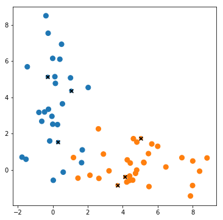

```python
plt.figure(figsize=(6, 6))
X_test = np.transpose(np.array([x1_test,x2_test]))
Y_test_predict = list(gnb.predict(X_test))
cols = [colordict[k] for k in df['Y'].values]
plt.scatter(df['X1'].values,df['X2'].values,color=cols,s=65)
cols = [colordict[k] for k in Y_test_predict]
plt.scatter(x1_test,x2_test,color=cols,s=35)
plt.scatter(x1_test,x2_test,marker='x',c='black',s=35)
plt.show()
```

### References

https://scikit-learn.org/stable/modules/naive_bayes.html  
https://www.geeksforgeeks.org/naive-bayes-classifiers/